# Qu'est ce que c'est l'impulsion specifique?

L'impulsion spécifique (l'Isp) est une mesure de l'efficacité avec laquelle un moteur crée une poussée. C'est la période en secondes pendant laquelle 1 kg de propergol produira une poussée de 1kg de force.

La poussée et l'impulsion spécifique ne doivent pas être confondues. La poussée est la force fournie par le moteur et dépend de la quantité de masse de réaction circulant dans le moteur. L'impulsion spécifique mesure l'impulsion produite par unité de propulseur et est proportionnelle à la vitesse d'échappement.

Dans un contexte atmosphérique, l'impulsion spécifique peut inclure la contribution à l'impulsion fournie par la masse d'air extérieur qui est accélérée par le moteur d'une manière ou d'une autre, comme par un turboréacteur interne ou le chauffage par la participation à la combustion du carburant puis l'expansion de la poussée ou par une hélice externe. Les moteurs à réaction respirent de l'air extérieur à la fois pour la combustion et le by-pass et ont donc une impulsion spécifique beaucoup plus élevée que les moteurs-fusées.

# Importation des fichiers

```python
from google.colab import drive
drive.mount('/content/drive')
```

Transformation du fichier en une liste de dictionnaires avec le module CSV

```python
import csv
with open("/content/drive/MyDrive/Trophee_NSI/Moteurs.csv", "r") as rfile:
  fdict = list(csv.DictReader(rfile, delimiter = ","))
```

Calulons d'abord les ISP manquants de certains moteurs dans notre fichier CSV avec Isp = (I/p) / g (I etant l'impulsion total et p etant le poids en N, et g l'intensite de pesanteur)

```python
g = 9.81
for dico in fdict:
  if dico['Isp'] == "":
    dico['Isp'] = str(round(float(dico['Total Impulse'].replace(",","").replace("Ns","").strip())/float(dico['Prop. Weight'].replace(",","").replace("g","").strip())/g/0.001 , 1 ))+ " s"
    print(f"{dico['Common Name']} possede un ISP de {dico['Isp']}")
```

```
M2505 possede un ISP de 227.4 s
M1540 possede un ISP de 191.8 s
J115 possede un ISP de 165.1 s
```

## Tris

Un système de propulsion avec une impulsion spécifique plus élevée utilise plus efficacement la masse du propulseur. Dans le cas d'une fusée, cela signifie moins de propulseur nécessaire pour un delta-v donné (utilisé dans la dynamique de vol des engins spatiaux, est une mesure de l'impulsion par unité de masse de l'engin spatial qui est nécessaire pour effectuer une manœuvre telle que le lancement ou l'atterrissage sur une planète ou une lune) afin que le véhicule attaché au moteur puisse gagner plus efficacement en altitude et en vitesse.

```python
DicoIsp = [{"Common Name": dico["Common Name"], "Isp": float(dico['Isp'].replace("s",""))} for dico in fdict]
print(DicoIsp)
```

```
[{'Common Name': 'J360', 'Isp': 204.0}, {'Common Name': 'M3100', 'Isp': 215.0}, {'Common Name': 'M2505', 'Isp': 227.4}, {'Common Name': 'M1670', 'Isp': 208.41}, {'Common Name': 'M1540', 'Isp': 191.8}, {'Common Name': 'M1400', 'Isp': 213.0}, {'Common Name': 'M1300', 'Isp': 191.0}, {'Common Name': 'J1…
```

```python
def insertion(tab, cle):
  for i in range(1, len(tab)):
    j = i
    while j>0 and tab[j-1][cle]>tab[j][cle]:
      tab[j-1], tab[j] = tab[j], tab[j-1]
      j = j-1
  return tab

IspSorted = insertion(DicoIsp, "Isp")
for fusee in IspSorted:
  print(fusee)
```

```
{'Common Name': 'J380', 'Isp': 138.0}
{'Common Name': 'J115', 'Isp': 165.1}
{'Common Name': 'M1300', 'Isp': 191.0}
{'Common Name': 'M1540', 'Isp': 191.8}
{'Common Name': 'J360', 'Isp': 204.0}
{'Common Name': 'M1670', 'Isp': 208.41}
{'Common Name': 'M1400', 'Isp': 213.0}
{'Common Name': 'M3100', 'Isp': 215.0}
{'Common Name': 'M2505', 'Isp': 227.4}
```

```python
print(f"Le {IspSorted[0]['Common Name']} possede le plus petit ISP de {IspSorted[0]['Isp']} parmi les fusées, donc c'est le moins efficace.")
print(f"Le {IspSorted[len(IspSorted)-1]['Common Name']} possede le plus grand ISP de {IspSorted[len(IspSorted)-1]['Isp']} parmi les fusées, donc c'est le plus efficace.")
```

```
Le J380 possede le plus petit ISP de 138.0 parmi les fusées, donc c'est le moins efficace.
Le M2505 possede le plus grand ISP de 227.4 parmi les fusées, donc c'est le plus efficace.
```

```python
g = 9.81 #Intensite de pesanteur
L_Ve = []
for i in range(len(DicoIsp)):
  DicoIsp[i]['Ve'] = round(DicoIsp[i]['Isp'] * g,2)
  print(f"Le {DicoIsp[i]['Common Name']} possede une vitesse d'echappemnt de {DicoIsp[i]['Ve']} m/s")
```

```
Le J380 possede une vitesse d'echappemnt de 1353.78 m/s
Le J115 possede une vitesse d'echappemnt de 1619.63 m/s
Le M1300 possede une vitesse d'echappemnt de 1873.71 m/s
Le M1540 possede une vitesse d'echappemnt de 1881.56 m/s
Le J360 possede une vitesse d'echappemnt de 2001.24 m/s
Le M1670 possede une vitesse d'echappemnt de 2044.5 m/s
Le M1400 possede une vitesse d'echappemnt de 2089.53 m/s
Le M3100 possede une vitesse d'echappemnt de 2109.15 m/s
Le M2505 possede une vitesse d'echappemnt de 2230.79 m/s
```

De plus cette proportionalité peut être obsérvée avec une représentation graphique

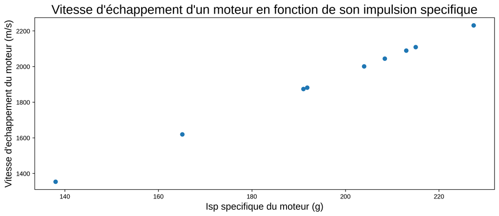

```python
import matplotlib.pyplot as plt


#création de listes contenant les valeurs du tableau
Ispmoteur = [fusee["Isp"] for fusee in DicoIsp]
L_Ve = [fusee["Ve"] for fusee in DicoIsp]
plt.figure(figsize=(13, 5), dpi=300)

plt.scatter(Ispmoteur,L_Ve)

plt.title("Vitesse d'échappement d'un moteur en fonction de son impulsion specifique", fontsize=20)
plt.xlabel('Isp specifique du moteur (g)', fontsize=15)
plt.ylabel("Vitesse d'echappement du moteur (m/s)", fontsize=15)
plt.style.use('seaborn-darkgrid')

plt.show()
```

De plus, l'impulsion spécifique est inversement proportionnelle à la consommation spécifique de carburant (SFC), qui est la quantité de carburant consommée par un véhicule pour chaque unité de puissance de sortie.: **Isp = 1/(g·SFC)** quand SFC est en kg/(N·s)

```python
g = 9.81 #Intensite de pesanteur
L_SFC = []
for i in range(len(DicoIsp)):
  DicoIsp[i]['SFC'] = 1/(DicoIsp[i]['Isp'] * g) *1000
  print(f"Le {DicoIsp[i]['Common Name']} possede une consommation specifique de carburant de {round(DicoIsp[i]['SFC'],2)} g/(N.s)")
```

```
Le J380 possede une consommation specifique de carburant de 0.74 g/(N.s)
Le J115 possede une consommation specifique de carburant de 0.62 g/(N.s)
Le M1300 possede une consommation specifique de carburant de 0.53 g/(N.s)
Le M1540 possede une consommation specifique de carburant de 0.53 g/(N.s)
Le J360 possede une consommation specifique de carburant de 0.5 g/(N.s)
Le M1670 possede une consommation specifique de carburant de 0.49 g/(N.s)
Le M1400 possede une consommation specifique de carburant de 0.48 g/(N.s)
Le M3100 possede une consommation specifique de carburant de 0.47 g/(N.s)
Le M2505 possede une consommation specifique de carburant de 0.45 g/(N.s)
```

Cette proportionnalite invérsée entre les deux peut être visualisée grâce à une représentation graphique.

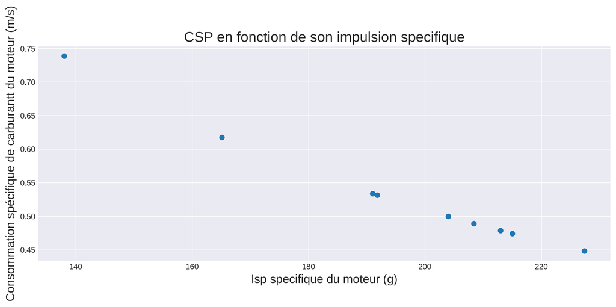

```python
import matplotlib.pyplot as plt

plt.figure(figsize=(13, 5), dpi=300)
L_SFC = [fusee["SFC"] for fusee in DicoIsp]

plt.scatter(Ispmoteur,L_SFC)

plt.title("CSP en fonction de son impulsion specifique", fontsize=18)
plt.xlabel('Isp specifique du moteur (g)', fontsize=15)
plt.ylabel("Consommation spécifique de carburantt du moteur (m/s)", fontsize=15)
plt.style.use('seaborn-darkgrid')

plt.show()
```

En effet, ce que nous observons est une partie d'hyperbole (nous sommes trop zoomés a cuase de l'echelle des variables, pourrait observer l'hyperbole en entier en agrandissant). Néanmoins, on peut remarquer que c'est inversement proportionnel.

```python
def tri_bulle(tab, cle):
    n = len(tab)
    for i in range(n):
        for j in range(0, n-i-1):
            if tab[j][cle] > tab[j+1][cle] :
                tab[j], tab[j+1] = tab[j+1], tab[j]
    return tab
SfcSorted = tri_bulle(DicoIsp, "SFC")
for fusee in SfcSorted:
  print(fusee)
```

```
{'Common Name': 'M2505', 'Isp': 227.4, 'Ve': 2230.79, 'SFC': 0.44827088471638343}
{'Common Name': 'M3100', 'Isp': 215.0, 'Ve': 2109.15, 'SFC': 0.4741246473697935}
{'Common Name': 'M1400', 'Isp': 213.0, 'Ve': 2089.53, 'SFC': 0.478576521992984}
{'Common Name': 'M1670', 'Isp': 208.41, 'Ve': 2044.5, 'SFC': 0.48911664116167936}
{'Common Name': 'J360', 'Isp': 204.0, 'Ve': 2001.24, 'SFC': 0.49969019208090976}
{'Common Name': 'M1540', 'Isp': 191.8, 'Ve': 1881.56, 'SFC': 0.5314744483029489}
{'Common Name': 'M1300', 'Isp': 191.0, 'Ve': 1873.71, 'SFC': 0.5337005192906052}
{'Common Name': 'J115', 'Isp': 165.1, 'Ve': 1619.63, 'SFC': 0.6174245862174779}
{'Common Name': 'J380', 'Isp': 138.0, 'Ve': 1353.78, 'SFC': 0.7386724578587363}
```

En triant la liste selon la SFC, la proportionnalité inverse est mise en évidence; plus la SFC augmente, plus le ISP diminue.

## Exportation des données en fichier CSV

```python
with open('MotorsISP.csv', "w") as nf:
  w = csv.DictWriter(nf, ['Common Name', 'Isp', 'Ve', 'SFC'])
  w.writeheader()
  w.writerows(DicoIsp)
```

# Conclusion:

Ainsi, nous pouvons faire plusieurs remarques en ce qui concerne l'ISP:

- Le moteur **M2505** est le moteur avec l'ISP le plus élevé, c'est le plus efficace et il possède la vitesse d'echappement de gaz la plus haute.
- Le moteur **J380** est le moteur avec l'ISP le moins élevé, c'est le moins efficace ce qui peut être aussi observé par le fait que il possède la consommation spécifique du carburant la plus élevée